# Uganda data set

Haziq Jamil

01/09/2018

## Uganda data set

First load the data set.

```r
X <- readxl::read_excel("../real-data/HAZ_UG.xls")
n <- nrow(X)
p <- ncol(X)
X <- as.matrix(X)
head(X)
```

```
##      CCA ELISA PCR KK1G KK2G
## [1,]   0     0   0    0    0
## [2,]   1     1   1    1    1
## [3,]   1     1   1    1    1
## [4,]   0     1   0    1    1
## [5,]   1     1   1    0    1
## [6,]   1     1   1    1    0
```

```r
dim(X)
```

```
## [1] 258   5
```

## Latent Class Model

Fit the data two ways: 1) Likelihood based method and 2) MCMC using JAGS.

### Likelihood based method (`randomLCA` package)

```r
(mod.lcm <- randomLCA(X, nclass = 2, probit = TRUE, seed = 123))
```

```
##   Classes      AIC      BIC     AIC3    logLik penlogLik
##         2 1210.585 1249.667 1221.585 -594.2923 -594.3472
## Class probabilities
## Class  1 Class  2
##   0.4791   0.5209
## Outcome probabilities
##              X1     X2     X3     X4     X5
## Class  1 0.9831 0.9835 0.9219 0.7929 0.7928
## Class  2 0.1897 0.5389 0.4469 0.0000 0.0001
```

It seems that Class 1 ($\delta = 1$) is the diseased class and Class 2 ($\delta = 2$) is non-diseased. The estimate of the prevalence $\tau := P(\delta = 1)$ is 0.479. Thus, the **sensitivities** $P(X_{ij} = 1 | \delta = 1)$ for each item is given by

```r
delta <- 1
sens.fit <- outcomeProbs(mod.lcm)[[delta]]
round(sens.fit, 3)
```

```
##    Outcome p 2.5 % 97.5 %
## X1     0.983 0.941  0.996
## X2     0.984 0.943  0.996
## X3     0.922 0.861  0.960
## X4     0.793 0.698  0.867
## X5     0.793 0.698  0.867
```

while the **specificities** are given by

```r
spec.fit <- 1 - outcomeProbs(mod.lcm)[[-delta]]
spec.fit[, 2:3] <- spec.fit[, 3:2]
round(spec.fit, 3)
```

```
##    Outcome p 2.5 % 97.5 %
## X1     0.810 0.722  0.879
## X2     0.461 0.375  0.549
## X3     0.553 0.465  0.639
## X4     1.000 0.000  1.000
## X5     1.000 0.000  1.000
```

The fitted frequency patterns are as follows:

```r
(fit.lcm <- fitted(mod.lcm))
```

```
##    X1 X2 X3 X4 X5 Freq     fitted
## 1   0  0  0  0  0   39 27.7743567
## 2   0  0  1  0  0   20 22.4386869
## 3   0  1  0  0  0   22 32.4706778
## 4   0  1  0  1  1    1  0.1009338
## 5   0  1  1  0  0   28 26.3070478
## 6   0  1  1  0  1    1  0.3128899
## 7   1  0  0  0  0    1  6.5069670
## 8   1  0  1  0  0    2  5.3303024
## 9   1  0  1  1  0    2  0.3028760
## 10  1  1  0  0  0   13  7.9985714
## 11  1  1  0  0  1    2  1.5341807
## 12  1  1  0  1  0    1  1.5342875
## 13  1  1  0  1  1    5  5.8705380
## 14  1  1  1  0  0   18 10.8656935
## 15  1  1  1  0  1   14 18.0927066
## 16  1  1  1  1  0   14 18.0974566
## 17  1  1  1  1  1   75 69.2539184
```

Calculate the (truncated) Pearson residuals:

```r
with(fit.lcm, {
  sum((Freq - fitted) ^ 2 / fitted)
})
```

```
## [1] 44.65433
```

### MCMC using JAGS

Let `d[i]` be the latent indicator vector of the diseased class, i.e. `d[i] = 1` if individual `i` is diseased, and `d[i] = 0` if healthy. If `d[i] = 1` then each item `X[i, j]` is Bernoulli with success probability `pi[j, 1]`, and conversely if `d[i] = 0` then each item `X[i, j]` is Bernoulli with success probability `pi[j, 2]`. The sensitivities are the first column of `pi`, and the specificities are one minus the second column of `pi`. Set diffuse priors for the prevalence `tau` and all entries in the `p` by `2` matrix `pi`. The JAGS model is as follows:

```r
mod.jags.lcm <- "model{
  for (i in 1:n) {
    d[i] ~ dbern(tau)
    for (j in 1:p) {
      pi.x[i, j] <- d[i] * pi[j, 1] + (1 - d[i]) * pi[j, 2]
      X[i, j] ~ dbern(pi.x[i, j])
    }
  }

  # Priors
  tau ~ dbeta(1, 1)
  for (j in 1:p) {
    pi[j, 1] ~ dbeta(1, 1)
    pi[j, 2] ~ dbeta(1, 1)
    # u[j] ~ dnorm(0, 0.001) I(0,)
    # pi[j, 2] = phi(probit(pi[j, 1]) - u[j])
  }

  # Sensitivities and specificities
  for (j  in 1:p) {
    sens[j] <- pi[j, 1]
    spec[j] <- 1 - pi[j, 2]
  }

}

#data# X, n, p
#monitor# tau, sens, spec, deviance
"
```

Supply the following initial values:

```r
inits <- list(
  tau = 0.1,
  d = rep(0, n),
  pi = matrix(c(0.9, 0.1), nrow = p, ncol = 2, byrow = TRUE)
)
```

Now run the model.

```r
(mod <- run.jags(mod.jags.lcm, n.chains = 8, sample = 4000, thin = 1,
                 inits = inits, burnin = 1600, adapt = 400, method = "parallel"))
```

```
## module lecuyer loaded
```

```
##
## JAGS model summary statistics from 32000 samples (chains = 8; adapt+burnin = 2000):
##
##          Lower95  Median Upper95    Mean       SD Mode      MCerr MC%ofSD
## tau      0.40503 0.47435  0.5409 0.47445 0.034554   -- 0.00028897     0.8
## sens[1]  0.95222 0.98162 0.99999 0.97887 0.013987   -- 0.00014706     1.1
## sens[2]   0.9519 0.98109 0.99999 0.97855 0.013884   -- 0.00014143       1
## sens[3]  0.86475  0.9177 0.96343 0.91547 0.025904   -- 0.00020621     0.8
## sens[4]  0.70686 0.79382  0.8744  0.7921 0.043287   --  0.0004609     1.1
## sens[5]  0.70517 0.79265 0.87235 0.79071 0.043252   --  0.0004539       1
## spec[1]  0.71987 0.80356 0.87924 0.80252 0.040891   -- 0.00043399     1.1
## spec[2]  0.37639 0.46031 0.55157 0.46099 0.044707   -- 0.00037173     0.8
## spec[3]  0.45923 0.54937 0.63453 0.54948 0.044853   -- 0.00035831     0.8
## spec[4]  0.96759 0.99181       1 0.98875 0.010634   -- 0.00015161     1.4
## spec[5]   0.9662 0.99086       1 0.98784 0.010822   -- 0.00013122     1.2
## deviance  861.28  878.37  900.84  879.67   10.535   --   0.096062     0.9
##
##          SSeff      AC.10   psrf
## tau      14299   0.019621 1.0003
## sens[1]   9046   0.012473 1.0004
## sens[2]   9637   0.018957 1.0003
## sens[3]  15781 -0.0046568      1
## sens[4]   8820   0.012106 1.0005
## sens[5]   9080   0.022518 1.0011
## spec[1]   8878   0.015648 1.0003
## spec[2]  14464 -0.0038465 1.0002
## spec[3]  15670  0.0036217 1.0002
## spec[4]   4920   0.077387 1.0008
## spec[5]   6802  0.0053249  1.001
## deviance 12028  0.0058863 1.0005
##
## Total time taken: 26.7 seconds
```

All MCMC diagnostics seem OK.

Now calculate fitted values manually. We use the posterior mean estimate of the sensitivities and specificities for this.

```r
tab.lcm <- summary(mod)[, c("Mean", "Lower95", "Upper95")]
fitted_mod(tab.lcm, X)
```

```
## $tab
##    CCA ELISA PCR KK1G KK2G Obs.       Exp.
## 1    0     0   0    0    0   39 26.9221273
## 2    0     0   1    0    0   20 22.0759395
## 3    0     1   0    0    0   22 31.4873251
## 4    0     1   0    1    1    1  0.1384326
## 5    0     1   1    0    0   28 25.9101781
## 6    0     1   1    0    1    1  0.6986556
## 7    1     0   0    0    0    1  6.6341450
## 8    1     0   1    0    0    2  5.5340940
## 9    1     0   1    1    0    2  0.4519451
## 10   1     1   0    0    0   13  8.1770930
## 11   1     1   0    0    1    2  1.7247358
## 12   1     1   0    1    0    1  1.7312961
## 13   1     1   0    1    1    5  6.2089533
## 14   1     1   1    0    0   18 11.0215200
## 15   1     1   1    0    1   14 17.7236702
## 16   1     1   1    1    0   14 17.8669660
## 17   1     1   1    1    1   75 67.2291111
##
## $chisq
## [1] 36.8461
```

## Latent Class Model with Random Effects

To relax the assumption of independence conditional on the true disease status, introduce individual specific random effects.

$$\begin{gather}
X_{ij}|\delta_i,u_i \sim \text{Bern}(\pi_{ij}) \\
\pi_{ij} =
\begin{cases}
\Phi(\beta_{0j} + \sigma_{0}u_i) &\text{if } \delta_i = 0 \\
\Phi(\beta_{1j} + \sigma_{1}u_i) &\text{if } \delta_i = 1 \\
\end{cases} \\
\delta_i \sim \text{Bern}(\tau) \\
u_i \sim \text{N}(0,1)
\end{gather}$$

The sensitivities and specificities are given by

$$\begin{align*}
\text{P}(X_{ij} = 1 | \delta_i = 1) &= \Phi\left( \frac{\beta_{1j}}{(1 + \sigma_1^2)^{1/2}} \right) \\
\text{P}(X_{ij} = 0 | \delta_i = 0) &= 1 - \Phi\left( \frac{\beta_{0j}}{(1 + \sigma_0^2)^{1/2}} \right) \\
\end{align*}$$

### Likelihood-based method (`randomLCA` package)

```r
(mod.lcmre <- randomLCA(X, nclass = 2, probit = TRUE,  random = TRUE,
                        quadpoints = 61, constload = TRUE, byclass = TRUE,
                        seed = 123))
```

```
##   Classes      AIC      BIC     AIC3    logLik penlogLik   Link
##         2 1190.767 1236.955 1203.767 -582.3835 -582.4989 Probit
## Class probabilities
## Class  1 Class  2
##   0.5522   0.4478
## Conditional outcome probabilities
##              X1     X2     X3     X4     X5
## Class  1 0.9973 0.9978 0.9357 0.7793 0.7709
## Class  2 0.0358 0.4831 0.4705 0.0000 0.0007
## Marginal Outcome Probabilities
##              X1     X2     X3     X4     X5
## Class  1 0.9619 0.9650 0.8337 0.6882 0.6819
## Class  2 0.0851 0.4871 0.4776 0.0001 0.0076
## Loadings
##
## Class  1 1.2078
## Class  2 0.8519
```

Class 1 is the diseased again (by looking at the conditional outcome probabilities). Now we get the **sensitivities** and **specificities**.

```r
delta <- 1
probs <- outcomeProbs(mod.lcmre, boot = TRUE, R = 30)
sens.fit <- probs[[delta]]
round(sens.fit, 3)
```

```
##    Outcome p 2.5 % 97.5 %
## X1     0.962 0.191  0.996
## X2     0.965 0.376  0.998
## X3     0.834 0.677  0.907
## X4     0.688 0.479  0.785
## X5     0.682 0.492  0.768
```

```r
spec.fit <- 1 - probs[[-delta]]
spec.fit[, 2:3] <- spec.fit[, 3:2]
round(spec.fit, 3)
```

```
##    Outcome p 2.5 % 97.5 %
## X1     0.915 0.418  0.996
## X2     0.513 0.408  0.616
## X3     0.522 0.420  0.624
## X4     1.000 0.997  1.000
## X5     0.992 0.672  1.000
```

And the fitted frequencies and residuals.

```r
(fit.lcmre <- fitted(mod.lcmre))
```

```
##    X1 X2 X3 X4 X5 Freq      fitted
## 1   0  0  0  0  0   39 39.24684708
## 2   0  0  1  0  0   20 19.13261209
## 3   0  1  0  0  0   22 21.75139128
## 4   0  1  0  1  1    1  0.08030823
## 5   0  1  1  0  0   28 28.98998643
## 6   0  1  1  0  1    1  0.66450617
## 7   1  0  0  0  0    1  2.35463080
## 8   1  0  1  0  0    2  2.08971735
## 9   1  0  1  1  0    2  0.25687318
## 10  1  1  0  0  0   13  9.33260211
## 11  1  1  0  0  1    2  3.21688263
## 12  1  1  0  1  0    1  3.35135097
## 13  1  1  0  1  1    5  3.58452487
## 14  1  1  1  0  0   18 17.89787521
## 15  1  1  1  0  1   14 14.36757662
## 16  1  1  1  1  0   14 14.74953645
## 17  1  1  1  1  1   75 74.73120756
```

```r
with(fit.lcmre, {
  sum((Freq - fitted) ^ 2 / fitted)
})
```

```
## [1] 27.55039
```

### MCMC using JAGS

```r
mod.jags.lcmre <- "
model{
  for (i in 1:n) {
    d[i] ~ dbern(tau)
    u[i] ~ dnorm(0, 1)
    for (j in 1:p) {
      u0[i, j] <- beta[j, 1] + sigma[1] * u[i]  # healthy
      u1[i, j] <- beta[j, 2] + sigma[2] * u[i]  # diseased
      pi.x[i, j] <- d[i] * phi(u1[i, j]) + (1 - d[i]) * phi(u0[i, j])
      X[i, j] ~ dbern(pi.x[i, j])
    }
  }

  # Priors
  tau ~ dbeta(1,1)
  for (j in 1:p) {
    beta[j, 1] ~ dnorm(0, 0.1)
    beta[j, 2] ~ dnorm(0, 0.1)
  }
  sigma[1] ~ dgamma(1, 1)
  sigma[2] ~ dgamma(1, 1)

  # Sensitivities and specificities
  for (j  in 1:p) {
    sens[j] <- phi(beta[j, 1] / sqrt(1 + pow(sigma[1], 2)))
    spec[j] <- 1 - phi(beta[j, 2] / sqrt(1 + pow(sigma[2], 2)))
  }
}

#data# X, n, p
#monitor# tau, sens, spec, deviance
"
```

Supply the following initial values:

```r
inits <- list(
  tau = 0.1,
  d = rep(0, n),
  beta = matrix(c(1, -1), nrow = p, ncol = 2, byrow = TRUE),
  sigma = c(1.5, 1.5)
)
```

Now run the model.

```r
(mod <- run.jags(mod.jags.lcmre, n.chains = 8, sample = 4000, thin = 1,
                 inits = inits, burnin = 1600, adapt = 400, method = "parallel"))
```

```
##
## JAGS model summary statistics from 32000 samples (chains = 8; adapt+burnin = 2000):
##
##             Lower95  Median Upper95    Mean       SD Mode     MCerr
## tau          0.1802 0.43968 0.82322 0.45659  0.15525   --  0.013751
## sens[1]     0.49365 0.85128       1 0.80093  0.16694   --  0.015125
## sens[2]      0.7359 0.93284       1 0.90191 0.087087   -- 0.0066333
## sens[3]     0.11247 0.73724 0.93947 0.65163  0.23039   --  0.023428
## sens[4]     0.19786 0.58065 0.83443 0.55224  0.16279   --  0.016396
## sens[5]     0.20392 0.58825 0.82915 0.56346  0.15708   --  0.015133
## spec[1]     0.38842 0.84832       1 0.77176  0.21227   --  0.022543
## spec[2]     0.20646 0.47137 0.63486 0.44661  0.11871   -- 0.0058627
## spec[3]  3.3307e-16 0.42516 0.58405 0.35366  0.18906   --  0.013768
## spec[4]     0.56994 0.98457       1 0.88694  0.15832   --  0.016149
## spec[5]     0.58156  0.9859       1  0.8974  0.15235   --   0.01153
## deviance     471.94  635.42  746.75  619.48   77.461   --    4.3931
##
##          MC%ofSD SSeff   AC.10   psrf
## tau          8.9   127 0.85448 1.2844
## sens[1]      9.1   122 0.89152 1.4353
## sens[2]      7.6   172  0.8367  1.164
## sens[3]     10.2    97  0.8896 1.5264
## sens[4]     10.1    99 0.86484 1.3896
## sens[5]      9.6   108 0.86477 1.3546
## spec[1]     10.6    89 0.88203 1.6304
## spec[2]      4.9   410 0.62543 1.3287
## spec[3]      7.3   189 0.82285 1.2808
## spec[4]     10.2    96 0.85526 1.6504
## spec[5]      7.6   175 0.81154 1.6259
## deviance     5.7   311  0.7158  1.409
##
## Total time taken: 2.4 minutes
```

Some MCMC diagnostic plots.

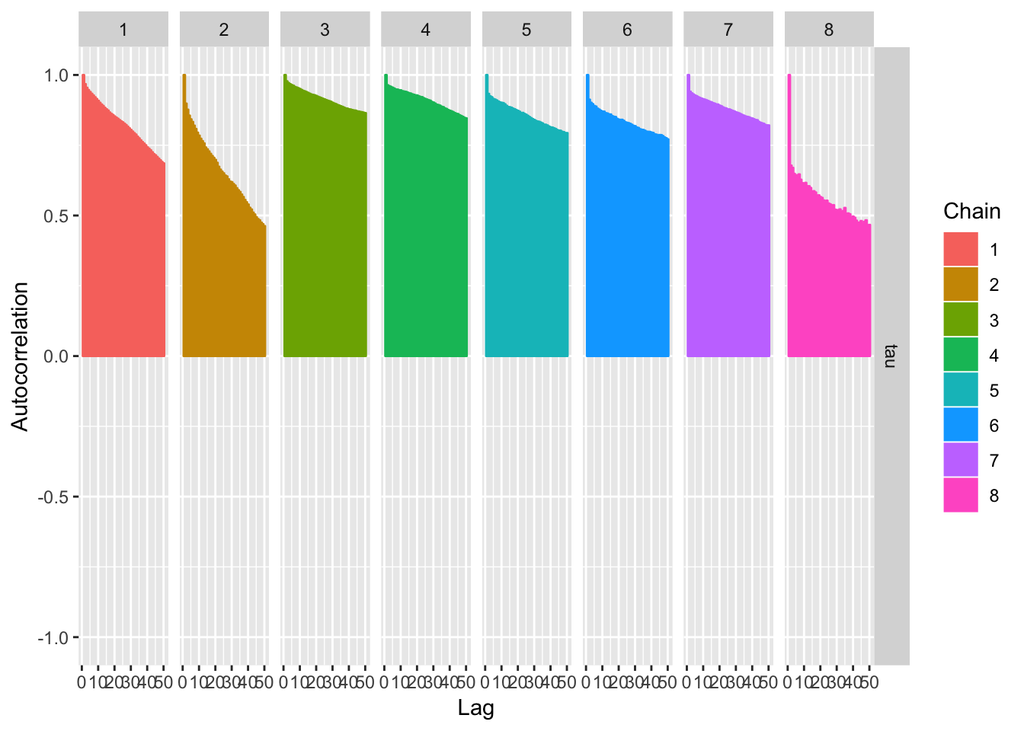

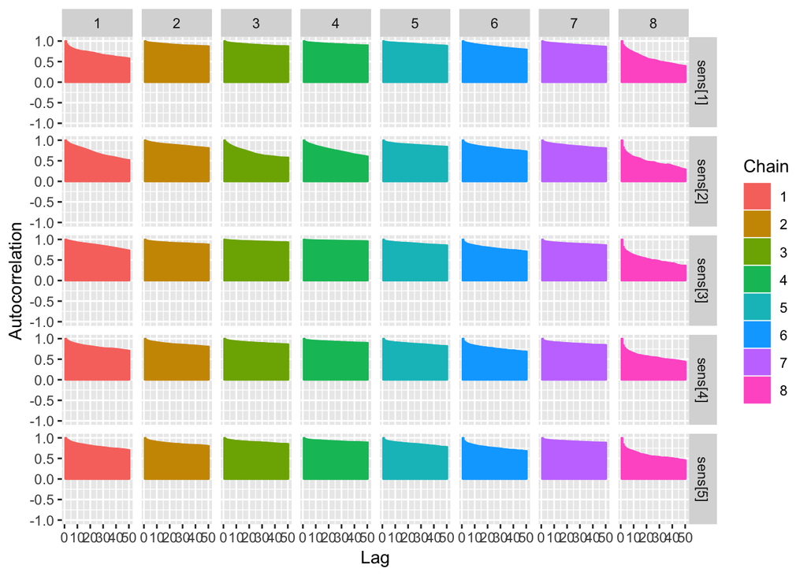

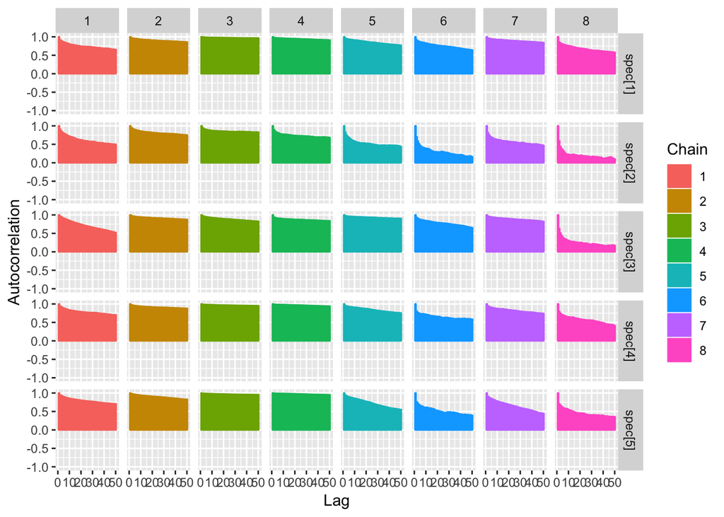

Poor diagnostics especially autocorrelation.

```r
tab.lcmre <- summary(mod)[, c("Mean", "Lower95", "Upper95")]
fitted_mod(tab.lcmre, X)
```

```
## $tab
##    CCA ELISA PCR KK1G KK2G Obs.      Exp.
## 1    0     0   0    0    0   39 13.759123
## 2    0     0   1    0    0   20 25.152757
## 3    0     1   0    0    0   22 18.295254
## 4    0     1   0    1    1    1  2.538411
## 5    0     1   1    0    0   28 33.498035
## 6    0     1   1    0    1    1  6.998990
## 7    1     0   0    0    0    1  4.652960
## 8    1     0   1    0    0    2  8.530749
## 9    1     0   1    1    0    2  2.390973
## 10   1     1   0    0    0   13 10.779120
## 11   1     1   0    0    1    2  8.049055
## 12   1     1   0    1    0    1  7.781961
## 13   1     1   0    1    1    5  9.297067
## 14   1     1   1    0    0   18 19.948500
## 15   1     1   1    0    1   14 15.031367
## 16   1     1   1    1    0   14 14.528954
## 17   1     1   1    1    1   75 17.387124
##
## $chisq
## [1] 267.1007
```

## Summary

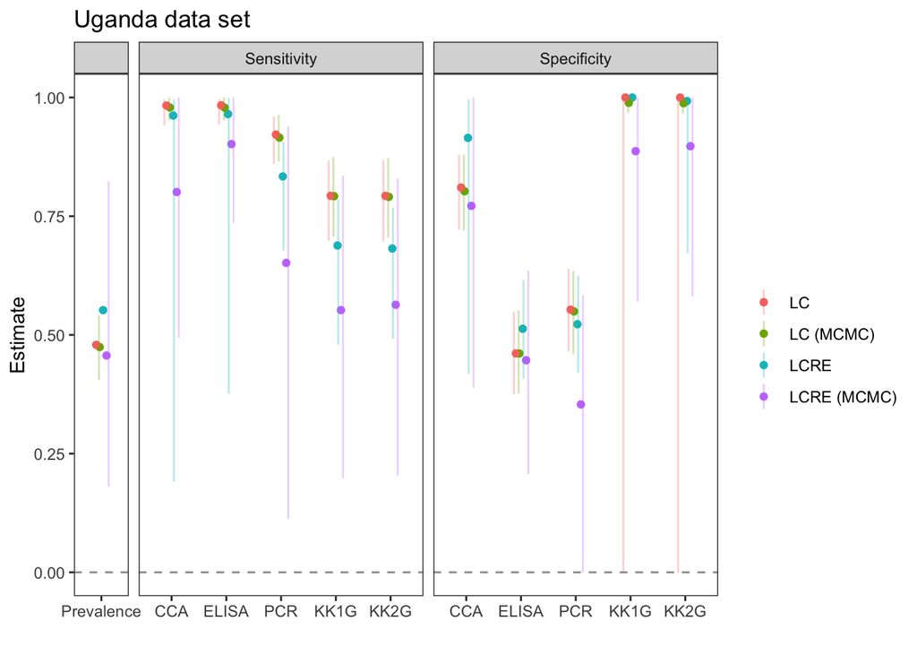

|  | Freq | LC | LC_MCMC | LCRE | LCRE_MCMC |
| --- | --- | --- | --- | --- | --- |
| 00000 | 39 | 27.774 | 26.922 | 39.247 | 13.759 |
| 00100 | 20 | 22.439 | 22.076 | 19.133 | 25.153 |
| 01000 | 22 | 32.471 | 31.487 | 21.751 | 18.295 |
| 01011 | 1 | 0.101 | 0.138 | 0.080 | 2.538 |
| 01100 | 28 | 26.307 | 25.910 | 28.990 | 33.498 |
| 01101 | 1 | 0.313 | 0.699 | 0.665 | 6.999 |
| 10000 | 1 | 6.507 | 6.634 | 2.355 | 4.653 |
| 10100 | 2 | 5.330 | 5.534 | 2.090 | 8.531 |
| 10110 | 2 | 0.303 | 0.452 | 0.257 | 2.391 |
| 11000 | 13 | 7.999 | 8.177 | 9.333 | 10.779 |
| 11001 | 2 | 1.534 | 1.725 | 3.217 | 8.049 |
| 11010 | 1 | 1.534 | 1.731 | 3.351 | 7.782 |
| 11011 | 5 | 5.871 | 6.209 | 3.585 | 9.297 |
| 11100 | 18 | 10.866 | 11.022 | 17.898 | 19.948 |
| 11101 | 14 | 18.093 | 17.724 | 14.368 | 15.031 |
| 11110 | 14 | 18.097 | 17.867 | 14.750 | 14.529 |
| 11111 | 75 | 69.254 | 67.229 | 74.731 | 17.387 |
| chisq | NA | 44.654 | 36.846 | 27.550 | 267.101 |
| deviance | NA | 1188.585 | 879.674 | 1164.767 | 619.482 |